# Community detection for coarse-graining clusters of mosquito habitats

This demo illustrates an artificial landscape of mosquito egg-laying and blood-feeding sites; creates a network of interactions between the different sites; and then uses network community detection to identify strongly interacting clusters of egg-laying sites.

## Generate Artificial Landscape

```r
# Create 32 feeding sites, defined by their (x,y) coordinates
xf <- c(rnorm(20, 2, 1), rnorm(10, 8, 1), rnorm(2, 7,.5))
yf <- c(rnorm(20, 3, 1), rnorm(10, 10, 1), rnorm(2,7,.5))
# Define the "attractiveness" weight of each feeding site
wf <- rgamma(length(xf), 5, 5)
# Create 29 egg laying sites, defined by their (x,y) coordinates
xl = c(rnorm(5, 2, .5), rnorm(14, 9, .5), rnorm(10, 8, .5))
yl = c(rnorm(5, 4, .5), rnorm(14, 4, .5), rnorm(10, 10, .5))
# Define the "attractiveness" weight of each egg laying site
wl = rgamma(length(xl), 5, 5)
```

### Show a plot of the Artificial Landscape

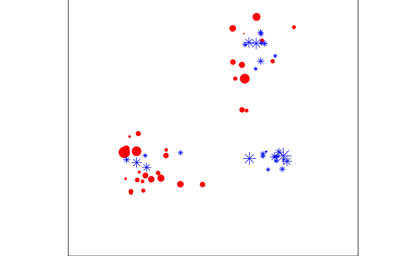

```r
par(mar=c(0,6,0,5))
# Plot blood feeding sites in Red
plot(xf, yf, pch = 19, col = "red", ylim = c(-1,12), xlim = c(-1,12), xlab = "", xaxt = "n", ylab = "", yaxt = "n", cex = wf, asp = 1)
# Plot egg laying sites in Blue
points(xl, yl, pch = 8, col = "blue", cex= wl)
```

## Generate Interaction Network

Next we want to express how mosquitoes travel around between these different sites. This is the interaction strength between the different sites. Here, we define two kernel functions that quantify how likely it is for a mosquito to travel from a feeding site to an egg-laying site, or from an egg-laying site to a feeding site. The kernel functions depend on the distances between the two sites and the attractiveness of the target site. (In practice, though, we can always find other ways to define the interaction strengths between different sites in the habitat.)

```r
# Calculate interaction strength between two sites (x,y) and (X,Y)
kerW <- function(x, y, X, Y, w, p=1){
  # Calculate the distance between the two sites (x,y) and (X,Y)
  d = sqrt( (x - X)^2 + (y - Y)^2)
  # Incorporate the attractiveness of the target site
  exp(-d*p)*w
}
# Vectorize:
# For a single point (x,y), return all interaction strengths between that point and the list of target points (XX, YY)
kerW.i <- function(i, x, y, XX, YY, w, p=1){
  kerW(x[i], y[i], XX, YY, w, p)
}
```

### Apply interaction kernels to the blood-feeding and egg-laying sites

What results is two weighted, non-diagonal, asymmetric matrices, LF and FL.  
* LF represents the interaction strength of traveling from each egg-laying site onto each blood-feeding site.  
* FL represents the interaction strength of traveling from each blood-feeding site onto each egg-laying site.

```r
# Interaction strength from each egg-laying site -> each blood-feeding site
LF = sapply(X=c(1:length(xl)), FUN=kerW.i, x=xl, y=yl, XX=xf, YY=yf, w=wf, simplify = "array")
# Interaction strength from each blood-feeding site -> each egg-laying site
FL = sapply(X=c(1:length(xf)), FUN=kerW.i, x=xf, y=yf, XX=xl, YY=yl, w=wl, simplify = "array")
# Transpose, because of R's axis conventions
LF = t(LF)
FL = t(FL)
# If you are confused about the axes of these matrices, try using dim(LF) and dim(FL) to count rows and columns, since there are different numbers of each type of site
```

### Find the interaction strength between the egg-laying sites with themselves

Mosquitoes in our model begin at an egg-laying site, fly to a blood-feeding site, and return to an egg-laying site. Each egg-laying site, therefore, has the potential to send mosquitoes to each other egg-laying site.

By taking the matrix product between LF and FL, we obtain a matrix that maps egg-laying sites back onto themselves.

```r
Q = LF%*%FL
# Row-normalize Q, so that it represents the probability of hopping for one egg-laying site to another egg-laying site
Q = Q / rowSums(Q)
# (To be honest, I'm not sure whether row-normalizing is correct here, but in practice we have total control over how we're defining these matrixes.)
```

### Matrix decomposition into symmetric and non-symmetric components

The matrix Q is weighted and asymmetric, where the asymmetry represents a net flow of mosquitoes from one site to another. Rather than rewrite Q to merely represent net flow between sites, we decompose Q into a symmetric component C and an asymmetric component N

```r
# Asymmetric piece
N = matrix(pmax(0, Q - t(Q)), length(xl), length(xl))
# Symmetric piece
C = Q-N
```

### Visualize the symmetric and non-symmetric components of the interaction network, showing how mosquitoes flow from one site to another

```r
par(mfrow=c(1,2))
par(mar=c(0,0,0,0))
# Symmetric component
plot(xl, yl, cex = .1,
     pch = 16, col = "blue", ylim = c(-1,12), xlim = c(-1,12),
     xlab = "", xaxt = "n", ylab = "", yaxt = "n")
title("Symmetric component C", line = -1)
```

```r
for(i in 1:length(xl))
  for(j in i:length(xl))
    segments(xl[i], yl[i], xl[j], yl[j], lwd = C[i,j])
# Asymmetric component, net flow on the landscape
plot(xl, yl, cex = .1,
    pch = 16, col = "blue", ylim = c(-1,12), xlim = c(-1,12),
    xlab = "", xaxt = "n", ylab = "", yaxt = "n", asp = 1)
```

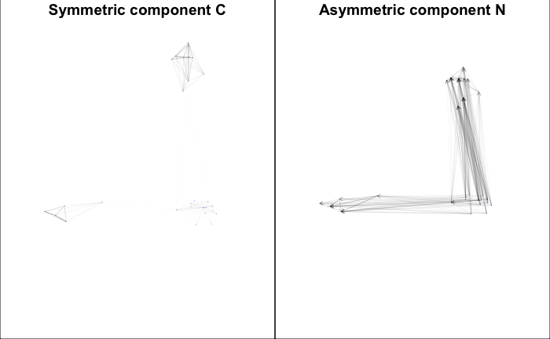

```r
title("Asymmetric component N", line = -1)
for(i in 1:length(xl))
  for(j in 1:length(xl))
    arrows(xl[i], yl[i], xl[j], yl[j], lwd = N[i,j], length = .05)
```

The main significance of the asymmetric component is that it shows net flows to and from the different egg-laying sites. We note that the arrows tend to point away from the lower right-hand corner towards each of the other two egg-laying sites. This is because those other egg-laying sites are closer to blood-feeding sites - essentially, mosquitoes leave the lower right-hand corner to move towards the blood-feeding sites and then end up in the other egg-laying sites because they are closer.

## Community structure analysis

We have created an artificial landscape with three artificially-grouped clusters of egg-laying sites. We have also generated a matrix Q that defines the rate at which mosquitoes jump from one egg-laying site to another, where the rates decrease with distance traveled.

Given that our artificial landscape has three artificially-grouped clusters of sites, and that the interactions between those sites depend on how those clusters are grouped in space, we should be able to use that information to group together the egg-laying sites into clusters that reflect how they are grouped in space. The matrix Q (as well as each of its components C+N) defines a network of interactions between each of the different sites, and we can use standard network clustering algorithms to define our communities. Then, we can use the net flow matrix N to find the net flows of mosquitoes between different clusters.

There are two possible strategies for accomplishing this, using Q, C, and N.

1. We can take the full asymmetric, directed, weighted adjacency matrix Q and run our network clustering algorithms on it - if we pick our clustering algorithms corectly, the results should respect both the strengths of the different connections as well as the net flow through the network.
2. We can run our clustering algorithms on the symmetric component C, and then use the asymmetric component N to determine net flow through the network. The advantage here is that clustering detection on directed networks is very difficult and most algorithms are optimized to work with symmetric matrices - it may be more straightforward to detect clusters using C and then considering the asymmetric flow separately.

### Convert our matrixes to igraph networks:

```r
qnet = graph_from_adjacency_matrix(Q, weighted = TRUE, mode = "directed")
qnet.n = graph_from_adjacency_matrix(N, weighted = TRUE, mode = "directed")
qnet.c = graph_from_adjacency_matrix(C, weighted = TRUE, mode = "undirected")
```

The network community detection literature is enormous, but igraph gives us a few options that are usable with weighted, asymmetric, directed adjacency networks.

1. Walktrap
- http://arxiv.org/abs/physics/0512106
- works with weighted, symmetric, undirected networks (C)
- this computes community structure using random walks to create a distance metric that is used to distinguish between “nearby” nodes in the same community from “faraway” nodes belonging to a different community
2. InfoMap
- https://arxiv.org/abs/0707.0609
- works with weighted, asymmetric, directed networks (N, C, or Q)
- Information-theoretical method for defining community structure. Uses random walks, but this time it searches for a minimum bit sequence required to describe a random walk assuming that it is more likely for random walkers to remain within a community than to leave a community

(There do exist other community detection algorithms that are applicable here, but they do not appear to behave properly with this particular example and so I have not included them.)